# Simulating Data

This module will cover:

- simulating data of discrete model
- simulating data of continuous model

which will require the following skills already covered:

- function syntax
- data structure
- assigning an object
- plotting in base `R`
- plotting in ggplot
- manipulating data

## Mathematical models

**Mathematical** or dynamical models are abstract models that uses mathematical language to describe the behavior of a system

### Logistic growth

A common model of population growth, originally proposed by to Pierre-François Verhulst in 1838, where the rate of reproduction is propoportional to both the existing population and the amount of available resources, all else being equal

### The logistic model discrete

$$n(t+1) = n(t) + r_d n(t) \left(1-\frac{n(t)}{K}\right)$$

Where $n(t+1)$ is new population size, $r$ is the growth rate, $K$ is the carrying capacity.

### How do we solve this in R

```r
disc.logistic = function(n, p) { ## here are just saying that 'disc.logistic' is a function that takes two arguments
  r = unname(p['r']) ## set the growth rate (dropping the parameter name with 'unname')
  K = unname(p['K']) ## set the carrying capacity
  n1 = n + r * n * (1 - n / K) ## calculate the new population size
  return(n1) ## and return it
}
```

```
Lets open Discrete_Model.R
```

### The logistic model continuous

In continuous models, we will explore a specific type of model: **ordinary differential equations**. These describe the *rate* at which variables changes over time

$$\frac{dN}{dt} = "function" N(t)$$

Where $N(t)$ is the value of a (continuous) variable at time.

Here **time** is the **independent variable** and **population size** ($N(t)$) is the dependent variable.

If we plot as a function of time, then the slope of the curve would be $\frac{dN}{dt}$. If the variable is increasing over time, the slope is positive; if it is decreasing, then it is negative.

We will need to numerically integrate the growth rate equation from time $t=0$ to time $t=T$

The **LSODA** adaptive step size solver in R is a powerful algorithm because it can automatically adjust its step size according to how rapidly the solution is changing.

```
require(deSolve) ## the packge we will uuse for this simulation

#The LSODA function takes in four (non-optional) arguments

out <- lsoda(nstart, times, func, params)
```

So the Logistic model in continuous time looks like this:

$$\frac{dn(t)}{dt} = r_c n(t) \left(1-\frac{n(t)}{K}\right).$$

### How do we solve this in R

```r
cont.logistic = function(n, p) { ## here are just saying that 'm.logistic' is a function that takes two arguments
  r = unname(p['r']) ## set the growth rate (dropping the parameter name with 'unname')
  K = unname(p['K']) ## set the carrying capacity
   ## calculate the rate of change
  dndt = r * n * (1 - n / K)
  ## return the rate of change as a list object (required by ode)
  list(c(dndt)) ## if you were calculating more than one derivative, you would have c(dn1dt,dn2dnt,etc.)
}
```

```
Lets open Continuous_Model.R
```

### SIR model

**Epidemiological processes** (e.g., infection of susceptible individuals, recovery of infected individuals). We will represent these with equations.

The classical $SIR$ compartmental model tracks the proportions of the population in each of three classes (susceptible, denoted by $S(t)$ , infectious $I(t)$ and recovered $R(t)$). Here the variables of interest are susceptible, infectious and recovered individuals. As the epidemic progresses, these quantities can change over time. The total population size does not change.

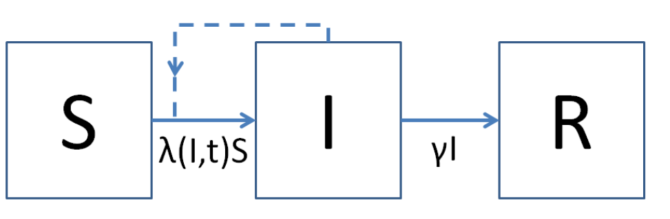

SIR model

$$\frac{dS}{dt} = -\lambda(I,t)S$$

$$\frac{dI}{dt} = \lambda(I,t)S-\gamma I$$

$$\frac{dR}{dt} = \gamma I$$

### How do we solve this in R

```r
SIRModel <- function (t, x, params) {

  # Computes the rate of change of the variables S, I and R over time
  #
  # Args:
  #   t: vector of time points in the integration
  #   x: vector of variables in the differential equation
  #   params: vector of parameter values
  #
  # Returns:
  #   The rate of change of the variables S, I and R.


  S <- x[1]                               #create local variable S, the first element of x
  I <- x[2]                               #create local variable I
  R <- x[3]                               #create local variable R


  with(                                   #we can simplify code using "with"
    as.list(params),                   #this argument to "with" lets us use the variable names
    {                                  #the system of rate equations

      N <- S + I + R

      dS <- -beta*S*I*(1/N)      ### make sure susceptibles are removed here (i.e. -beta*S*I/N)
      dI <- beta*S*I*(1/N)-gamma*I
      dR <- gamma*I
      dx <- c(dS,dI,dR)                #combine results into a single vector dx
      list(dx)                         #return result as a list,
      #note order must be same as the state variables
    }
  )
}
```

```
Lets open SIR_Deterministic.R
```